# Exercise 1: creating a document

Author

Matteo Pini

Published

November 27, 2026

# 1 Loading the dataset “Sara_dataset” into R

```r
rm(list=ls())
library(tidyverse)
library(see)
```

```r
library(readxl)
Sara_data<-read_excel("Sara_dataset.xls",col_names = TRUE)
```

# 2 Describing variables

```r
glimpse(Sara_data)
```

```
Rows: 100
Columns: 13
$ gender   <dbl> 1, 1, 1, 1, 1, 1, 1, 1, 1, 1, 1, 1, 1, 1, 1, 1, 1, 1, 1, 1, 1…
$ major    <dbl> 1, 1, 1, 1, 1, 1, 1, 1, 1, 1, 1, 1, 1, 1, 1, 1, 1, 1, 1, 2, 2…
$ cond     <dbl> 1, 1, 1, 1, 1, 2, 2, 2, 2, 2, 4, 2, 2, 3, 4, 4, 2, 4, 4, 1, 1…
$ phobia   <dbl> 1, 1, 4, 4, 10, 4, 4, 4, 4, 5, 3, 5, 4, 4, 8, 4, 7, 0, 5, 4, …
$ prevmath <dbl> 3, 4, 1, 0, 1, 1, 2, 1, 1, 0, 1, 1, 0, 1, 0, 1, 0, 3, 1, 2, 2…
$ mathquiz <dbl> 43, 49, 26, 29, 31, 20, 13, 23, 38, NA, 21, 29, 32, NA, NA, 3…
$ statquiz <dbl> 6, 9, 8, 7, 6, 7, 3, 7, 8, 7, 8, 8, 8, 5, 3, 8, 1, 10, 7, 7, …
$ hr_base  <dbl> 71, 73, 69, 72, 71, 70, 71, 77, 73, 78, 72, 74, 73, 72, 76, 6…
$ hr_pre   <dbl> 68, 75, 76, 73, 83, 71, 70, 87, 72, 76, 74, 72, 74, 83, 76, 6…
$ hr_post  <dbl> 65, 68, 72, 78, 74, 76, 66, 84, 67, 74, 68, 73, 74, 77, 79, 7…
$ anx_base <dbl> 17, 17, 19, 19, 26, 12, 12, 17, 20, 20, 21, 21, 32, 18, 14, 1…
$ anx_pre  <dbl> 22, 19, 14, 13, 30, 15, 16, 19, 14, 24, 27, 25, 35, 27, 18, 1…
$ anx_post <dbl> 20, 16, 15, 16, 25, 19, 17, 22, 17, 19, 22, 22, 33, 28, 21, 1…
```

*gender*  
*major*  
*cond*  
*phobia*  
*prevmath*  
*mathquiz*  
*statquiz*  
*hr* *base**, hr* *pre**, hr* *post*  
*anx base, anx* *pre**, anx post*

Participants’ gender  
Type of undergraduate degree obtained  
Experimental condition  
Self-reported fear of mathematics  
Number of mathematics courses previously attended  
Score on a mathematics pre-test  
Score on a statistics test  
Heart rate under normal conditions, before and after the test  
Anxiety test scores under normal conditions, before and after the test

```r
summary(Sara_data)
```

```
     gender         major           cond          phobia         prevmath
 Min.   :1.00   Min.   :1.00   Min.   :1.00   Min.   : 0.00   Min.   :0.00
 1st Qu.:1.00   1st Qu.:1.00   1st Qu.:1.75   1st Qu.: 1.00   1st Qu.:1.00
 Median :1.00   Median :2.00   Median :2.50   Median : 3.00   Median :1.00
 Mean   :1.43   Mean   :2.52   Mean   :2.50   Mean   : 3.31   Mean   :1.38
 3rd Qu.:2.00   3rd Qu.:3.25   3rd Qu.:3.25   3rd Qu.: 4.00   3rd Qu.:2.00
 Max.   :2.00   Max.   :5.00   Max.   :4.00   Max.   :10.00   Max.   :6.00

    mathquiz        statquiz        hr_base          hr_pre         hr_post
 Min.   : 9.00   Min.   : 1.00   Min.   :64.00   Min.   :62.00   Min.   :64.0
 1st Qu.:22.00   1st Qu.: 6.00   1st Qu.:70.00   1st Qu.:70.00   1st Qu.:69.0
 Median :30.00   Median : 7.00   Median :72.00   Median :74.00   Median :73.0
 Mean   :29.07   Mean   : 6.86   Mean   :72.27   Mean   :73.85   Mean   :72.8
 3rd Qu.:35.00   3rd Qu.: 8.00   3rd Qu.:74.00   3rd Qu.:78.00   3rd Qu.:76.0
 Max.   :49.00   Max.   :10.00   Max.   :80.00   Max.   :87.00   Max.   :86.0
 NA's   :15
    anx_base        anx_pre         anx_post
 Min.   :10.00   Min.   : 8.00   Min.   : 9.0
 1st Qu.:16.00   1st Qu.:14.00   1st Qu.:16.0
 Median :18.00   Median :19.00   Median :19.0
 Mean   :18.43   Mean   :19.58   Mean   :19.4
 3rd Qu.:20.00   3rd Qu.:25.00   3rd Qu.:22.0
 Max.   :39.00   Max.   :39.00   Max.   :40.0
```

# 3 Analising two variables

We can try taking a look at a possible association between the type of degree obtained and the self-reported fear of mathematics using a boxplot:

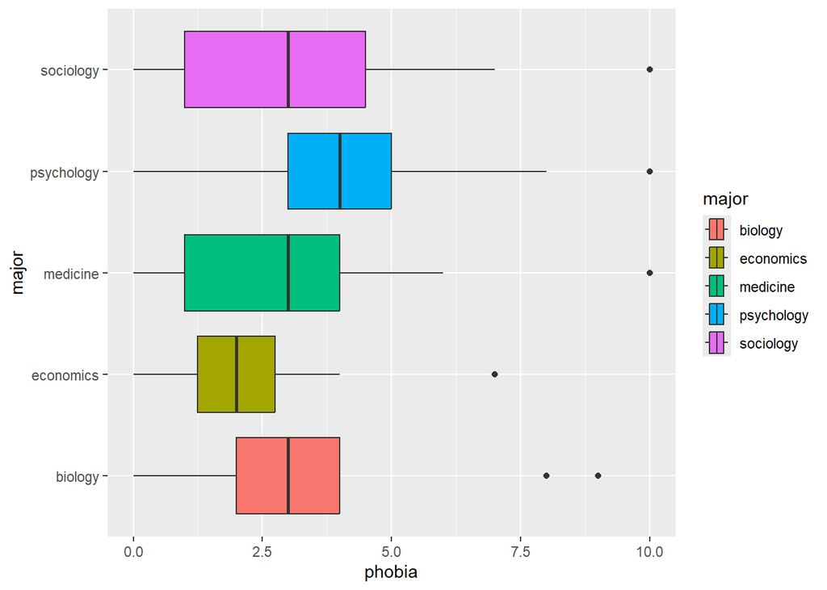

There’s an interesting cross-cultural study (Hamza & Helal, 2013) focusing also to different educational systems.

## 3.1 “R” we stupid?

Taking a look at the previous graph we could speculate and ask ourselves if mathematics fear in psychology students could imply worse results in the math pre-test and the statistics test, just like the child below.

[figure not shown]

We’ll analyse a possible association between the type of degree obtained and the scores in both the pre-test and the test using two half violin plots:

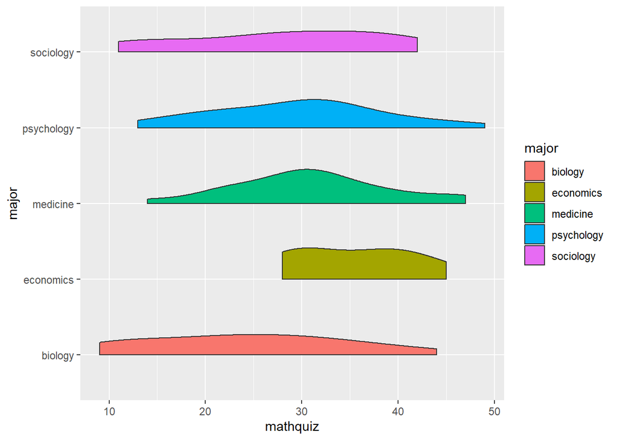

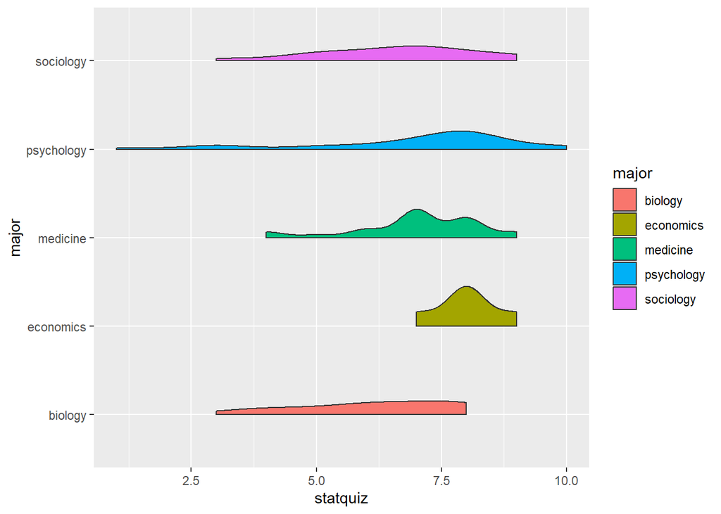

# 4 Conclusions

In this exercise, I’ve loaded a dataset in R, briefly described its variables, analysed possible associations between variables and learned that we, as psychology students, can be generally scared of math while still being smart and cool when we’re talking about statistics (all of this thanks to prof. Altoè and the entire team of Psicostat).

## References

Hamza, E. G. A., & Helal, A. M. (2013). Maths anxiety in college students across majors: A cross-cultural study. *British Education Studies Association, Educational Futures*, *5*, 58–61.